# Seguimiento 1 - Notebook

# Seguimiento 1

## Equipo 9

- Ángel Marín Rodríguez
- Marcos Eduardo Guzmán Marcillo
- Rubén Jiménez Jiménez
- Elena Berdugo Rodríguez
- Tim Lindner

**Dataset:** [Kepler Exoplanet Search Results](https://www.kaggle.com/datasets/nasa/kepler-exoplanet-search-results)

## Introducción

Hemos escogido un dataset con temática de exoplanetas. Un exoplaneta es un planeta no perteneciente a nuestro sistema solar. El dataset utiliza información recuperada gracias al telescopio espacial Johannes Kepler, y cuenta con unos 10000 ejemplos de datos.

*Proceso de Kepler* 1. Un evento TCE (Threshold Crossing Event) alarma al sistema automático de Kepler que una de las estrellas ha bajado en luminosidad de manera frecuente.

2. Luego algoritmos automáticos y finalmente expertos humanos verifican candidatos.

A priori estimamos viable un problema típico de clasificación para el estatus del planeta (candidato, falso positivo, confirmado), pero tenemos intención de abordarlo también con aprendizaje no supervisado, clustering por ejemplo, los planetas en función de sus características. Hablando de las características, son algo técnicas, pero pasamos a describirlas brevemente a continuación:

*Identificadores*

- kepid: Identificador único del objetivo observado por el telescopio Kepler.
- kepoi_name: Nombre asignado al objeto candidato a exoplaneta.

*Archivo de Exoplanetas*

- kepler_name: Nombre oficial del exoplaneta confirmado (si existe).
- koi_disposition: Estado del candidato del la comunidad científica (CONFIRMED, FALSE POSITIVE o CANDIDATE).

*Resultados del Proyecto Kepler*

- koi_pdisposition: Clasificación de la misión Kepler (CANDIDATE o FALSE POSITIVE).
- koi_score: Probabilidad (confianza) de que el objeto sea un planeta real. Para CANDIDATE un valor alto representa alta confianza, mientras para FALSE POSITIVE un valor alto representa una confianza baja en esta disposición.
- koi_fpflag_nt: falso positivo por un tránsito no es de origen planetario.
- koi_fpflag_ss: falso positivo por equivocación con un sistema estelar binario.
- koi_fpflag_co: falso positivo por un tránsito contaminado por una fuente cercana.
- koi_fpflag_ec: falso positivo por un tránsito que podría ser causado por una eclipsante estelar.

*Información sobre TCE (Threshold Crossing Event)*

- koi_model_snr: koi_depth normalizado por fluctuación regular de la luz de la estrella. Indica la fiabilidad del señal
- koi_tce_plnt_num: Número del planeta dentro del sistema (1, 2, 3…).
- koi_tce_delivname: Versión de los datos del catálogo TCE.

*Propriedades del Tránsito*

- koi_period: Periodo orbital del planeta en días.
- koi_time0bk: Tiempo (BJD) del primer tránsito observado.
- koi_impact: Impacto del tránsito (delante del centro de la estrella (valor cercano a 0) o más cerca del borde (valor cercano a 1) o apenas roza la estrella (valor >1 a menudo significa que falla o está rozando))
- koi_duration: Duración del tránsito en horas.
- koi_depth: Profundidad del tránsito (cuanta luz bloqueó) en partes por millón. Indica el tamaño del planeta.
- koi_prad: Radio del planeta en radios terrestres.
- koi_teq: Temperatura de equilibrio del planeta (K).
- koi_insol: Flujo estelar recibido por el planeta en unidades terrestres.
- koi_prad_err1: Error superior en el radio planetario.
- koi_prad_err2: Error inferior en el radio planetario.
- koi_teq_err1: Error superior en la temperatura de equilibrio. [100% Null]
- koi_teq_err2: Error inferior en la temperatura de equilibrio. [100% Null]
- koi_insol_err1: Error superior en el flujo incidente.
- koi_insol_err2: Error inferior en el flujo incidente.
- koi_period_err1: Error superior en el periodo orbital.
- koi_period_err2: Error inferior en el periodo orbital.
- koi_time0bk_err1: Error superior en el tiempo de tránsito.
- koi_time0bk_err2: Error inferior en el tiempo de tránsito.
- koi_duration_err1: Error superior en la duración del tránsito.
- koi_duration_err2: Error inferior en la duración del tránsito.
- koi_depth_err1: Error superior en la profundidad del tránsito.
- koi_depth_err2: Error inferior en la profundidad del tránsito.
- koi_impact_err1: Error inferior en el impacto del tránsito.
- koi_impact_err2: Error inferior en el impacto del tránsito.

*Parámetros estrelares*

- ra: Ascensión recta de la estrella (grados).
- dec: Declinación de la estrella (grados).
- koi_kepmag: Magnitud Kepler de la estrella.
- koi_steff: Temperatura efectiva de la estrella anfitriona (K).
- koi_slogg: Gravedad superficial de la estrella (log g, cgs).
- koi_srad: Radio estelar en radios solares.
- koi_steff_err1: Error superior en la temperatura estelar.
- koi_steff_err2: Error inferior en la temperatura estelar.
- koi_slogg_err1: Error superior en la gravedad estelar.
- koi_slogg_err2: Error inferior en la gravedad estelar.
- koi_srad_err1: Error superior en el radio estelar.
- koi_srad_err2: Error inferior en el radio estelar.

*No incluidos en el dataset de Kaggle*

- koi_count: Número de observaciones disponibles.
- koi_eccen: Excentricidad orbital (0 = circular).
- koi_model_snr_err: Error en la relación señal/ruido.
- koi_longp: Longitud del periastro (en grados).
- y más … https://exoplanetarchive.ipac.caltech.edu/cgi-bin/TblView/nph-tblView?app=ExoTbls&config=cumulative

## Estudio Inicial

Realizamos la carga de librerías, datos, y algún análisis inicial.

```r
library(tidyverse)
library(dplyr)
#library(readr)
#library(scales)
library(ggplot2)
```

- Cargamos los datos

```r
kepler <- read_csv("data/cumulative.csv")
```

- Resumen de datos con head - Tenemos 50 columnas, que son bastantes, tendremos que ver cómo hacer seleccion de atributos para quedarnos con menos seguramente, aunque teniendo 10000 ejemplos antes de realizar un estudio de su estado, parece prometedor.

```r
head(kepler)
```

| rowid | kepid | kepoi_name | kepler_name | koi_disposition | koi_pdisposition | koi_score | koi_fpflag_nt | koi_fpflag_ss | koi_fpflag_co | koi_fpflag_ec | koi_period | koi_period_err1 | koi_period_err2 | koi_time0bk | koi_time0bk_err1 | koi_time0bk_err2 | koi_impact | koi_impact_err1 | koi_impact_err2 | koi_duration | koi_duration_err1 | koi_duration_err2 | koi_depth | koi_depth_err1 | koi_depth_err2 | koi_prad | koi_prad_err1 | koi_prad_err2 | koi_teq | … |
| --- | --- | --- | --- | --- | --- | --- | --- | --- | --- | --- | --- | --- | --- | --- | --- | --- | --- | --- | --- | --- | --- | --- | --- | --- | --- | --- | --- | --- | --- | --- |
| 1 | 10797460 | K00752.01 | Kepler-227 b | CONFIRMED | CANDIDATE | 1.000 | 0 | 0 | 0 | 0 | 9.488036 | 2.775e-05 | -2.775e-05 | 170.5387 | 0.002160 | -0.002160 | 0.146 | 0.318 | -0.146 | 2.95750 | 0.08190 | -0.08190 | 615.8 | 19.5 | -19.5 | 2.26 | 0.26 | -0.15 | 793 | … |
| 2 | 10797460 | K00752.02 | Kepler-227 c | CONFIRMED | CANDIDATE | 0.969 | 0 | 0 | 0 | 0 | 54.418383 | 2.479e-04 | -2.479e-04 | 162.5138 | 0.003520 | -0.003520 | 0.586 | 0.059 | -0.443 | 4.50700 | 0.11600 | -0.11600 | 874.8 | 35.5 | -35.5 | 2.83 | 0.32 | -0.19 | 443 | … |
| 3 | 10811496 | K00753.01 | NA | FALSE POSITIVE | FALSE POSITIVE | 0.000 | 0 | 1 | 0 | 0 | 19.899140 | 1.494e-05 | -1.494e-05 | 175.8503 | 0.000581 | -0.000581 | 0.969 | 5.126 | -0.077 | 1.78220 | 0.03410 | -0.03410 | 10829.0 | 171.0 | -171.0 | 14.60 | 3.92 | -1.31 | 638 | … |
| 4 | 10848459 | K00754.01 | NA | FALSE POSITIVE | FALSE POSITIVE | 0.000 | 0 | 1 | 0 | 0 | 1.736952 | 2.630e-07 | -2.630e-07 | 170.3076 | 0.000115 | -0.000115 | 1.276 | 0.115 | -0.092 | 2.40641 | 0.00537 | -0.00537 | 8079.2 | 12.8 | -12.8 | 33.46 | 8.50 | -2.83 | 1395 | … |
| 5 | 10854555 | K00755.01 | Kepler-664 b | CONFIRMED | CANDIDATE | 1.000 | 0 | 0 | 0 | 0 | 2.525592 | 3.761e-06 | -3.761e-06 | 171.5956 | 0.001130 | -0.001130 | 0.701 | 0.235 | -0.478 | 1.65450 | 0.04200 | -0.04200 | 603.3 | 16.9 | -16.9 | 2.75 | 0.88 | -0.35 | 1406 | … |
| 6 | 10872983 | K00756.01 | Kepler-228 d | CONFIRMED | CANDIDATE | 1.000 | 0 | 0 | 0 | 0 | 11.094321 | 2.036e-05 | -2.036e-05 | 171.2012 | 0.001410 | -0.001410 | 0.538 | 0.030 | -0.428 | 4.59450 | 0.06100 | -0.06100 | 1517.5 | 24.2 | -24.2 | 3.90 | 1.27 | -0.42 | 835 | … |

Tenemos un total de 9564 Exoplanetas, con 49 Características, de las que 22 se refieren a errores de otros atributos.

```r
str(kepler)
```

```
spc_tbl_ [9,564 × 50] (S3: spec_tbl_df/tbl_df/tbl/data.frame)
 $ rowid            : num [1:9564] 1 2 3 4 5 6 7 8 9 10 ...
 $ kepid            : num [1:9564] 10797460 10797460 10811496 10848459 10854555 ...
 $ kepoi_name       : chr [1:9564] "K00752.01" "K00752.02" "K00753.01" "K00754.01" ...
 $ kepler_name      : chr [1:9564] "Kepler-227 b" "Kepler-227 c" NA NA ...
 $ koi_disposition  : chr [1:9564] "CONFIRMED" "CONFIRMED" "FALSE POSITIVE" "FALSE POSITIVE" ...
 $ koi_pdisposition : chr [1:9564] "CANDIDATE" "CANDIDATE" "FALSE POSITIVE" "FALSE POSITIVE" ...
 $ koi_score        : num [1:9564] 1 0.969 0 0 1 1 1 0.992 0 1 ...
 $ koi_fpflag_nt    : num [1:9564] 0 0 0 0 0 0 0 0 0 0 ...
 $ koi_fpflag_ss    : num [1:9564] 0 0 1 1 0 0 0 0 1 0 ...
 $ koi_fpflag_co    : num [1:9564] 0 0 0 0 0 0 0 0 1 0 ...
 $ koi_fpflag_ec    : num [1:9564] 0 0 0 0 0 0 0 0 0 0 ...
 $ koi_period       : num [1:9564] 9.49 54.42 19.9 1.74 2.53 ...
 $ koi_period_err1  : num [1:9564] 2.78e-05 2.48e-04 1.49e-05 2.63e-07 3.76e-06 ...
 $ koi_period_err2  : num [1:9564] -2.78e-05 -2.48e-04 -1.49e-05 -2.63e-07 -3.76e-06 ...
 $ koi_time0bk      : num [1:9564] 171 163 176 170 172 ...
 $ koi_time0bk_err1 : num [1:9564] 0.00216 0.00352 0.000581 0.000115 0.00113 0.00141 0.0019 0.00461 0.00253 0.000517 ...
 $ koi_time0bk_err2 : num [1:9564] -0.00216 -0.00352 -0.000581 -0.000115 -0.00113 -0.00141 -0.0019 -0.00461 -0.00253 -0.000517 ...
 $ koi_impact       : num [1:9564] 0.146 0.586 0.969 1.276 0.701 ...
 $ koi_impact_err1  : num [1:9564] 0.318 0.059 5.126 0.115 0.235 ...
 $ koi_impact_err2  : num [1:9564] -0.146 -0.443 -0.077 -0.092 -0.478 -0.428 -0.532 -0.523 -0.044 -0.052 ...
 $ koi_duration     : num [1:9564] 2.96 4.51 1.78 2.41 1.65 ...
 $ koi_duration_err1: num [1:9564] 0.0819 0.116 0.0341 0.00537 0.042 0.061 0.0673 0.165 0.136 0.0241 ...
 $ koi_duration_err2: num [1:9564] -0.0819 -0.116 -0.0341 -0.00537 -0.042 -0.061 -0.0673 -0.165 -0.136 -0.0241 ...
 $ koi_depth        : num [1:9564] 616 875 10829 8079 603 ...
 $ koi_depth_err1   : num [1:9564] 19.5 35.5 171 12.8 16.9 24.2 18.7 16.8 5.8 33.3 ...
 $ koi_depth_err2   : num [1:9564] -19.5 -35.5 -171 -12.8 -16.9 -24.2 -18.7 -16.8 -5.8 -33.3 ...
 $ koi_prad         : num [1:9564] 2.26 2.83 14.6 33.46 2.75 ...
 $ koi_prad_err1    : num [1:9564] 0.26 0.32 3.92 8.5 0.88 1.27 0.9 0.52 6.45 0.22 ...
 $ koi_prad_err2    : num [1:9564] -0.15 -0.19 -1.31 -2.83 -0.35 -0.42 -0.3 -0.17 -9.67 -0.49 ...
 $ koi_teq          : num [1:9564] 793 443 638 1395 1406 ...
 $ koi_teq_err1     : logi [1:9564] NA NA NA NA NA NA ...
 $ koi_teq_err2     : logi [1:9564] NA NA NA NA NA NA ...
 $ koi_insol        : num [1:9564] 93.59 9.11 39.3 891.96 926.16 ...
 $ koi_insol_err1   : num [1:9564] 29.45 2.87 31.04 668.95 874.33 ...
 $ koi_insol_err2   : num [1:9564] -16.65 -1.62 -10.49 -230.35 -314.24 ...
 $ koi_model_snr    : num [1:9564] 35.8 25.8 76.3 505.6 40.9 ...
 $ koi_tce_plnt_num : num [1:9564] 1 2 1 1 1 1 2 3 1 1 ...
 $ koi_tce_delivname: chr [1:9564] "q1_q17_dr25_tce" "q1_q17_dr25_tce" "q1_q17_dr25_tce" "q1_q17_dr25_tce" ...
 $ koi_steff        : num [1:9564] 5455 5455 5853 5805 6031 ...
```

[output cut: 50 more lines]

```
  ..   koi_tce_delivname = col_character(),
  ..   koi_steff = col_double(),
  ..   koi_steff_err1 = col_double(),
  ..   koi_steff_err2 = col_double(),
  ..   koi_slogg = col_double(),
  ..   koi_slogg_err1 = col_double(),
  ..   koi_slogg_err2 = col_double(),
  ..   koi_srad = col_double(),
  ..   koi_srad_err1 = col_double(),
  ..   koi_srad_err2 = col_double(),
  ..   ra = col_double(),
  ..   dec = col_double(),
  ..   koi_kepmag = col_double()
  .. )
 - attr(*, "problems")=<externalptr>
```

```r
dim(kepler)
```

```
[1] 9564   50
```

Viendo el resumen del dataset - Puede ser relevante emplear alguna de estas métricas

```r
summary(kepler)
```

```
     rowid          kepid           kepoi_name        kepler_name        koi_disposition    koi_pdisposition     koi_score      koi_fpflag_nt    koi_fpflag_ss
 Min.   :   1   Min.   :  757450   Length:9564        Length:9564        Length:9564        Length:9564        Min.   :0.0000   Min.   :0.0000   Min.   :0.0000
 1st Qu.:2392   1st Qu.: 5556034   Class :character   Class :character   Class :character   Class :character   1st Qu.:0.0000   1st Qu.:0.0000   1st Qu.:0.0000
 Median :4782   Median : 7906892   Mode  :character   Mode  :character   Mode  :character   Mode  :character   Median :0.3340   Median :0.0000   Median :0.0000
 Mean   :4782   Mean   : 7690628                                                                               Mean   :0.4808   Mean   :0.1882   Mean   :0.2316
 3rd Qu.:7173   3rd Qu.: 9873066                                                                               3rd Qu.:0.9980   3rd Qu.:0.0000   3rd Qu.:0.0000
 Max.   :9564   Max.   :12935144                                                                               Max.   :1.0000   Max.   :1.0000   Max.   :1.0000
                                                                                                               NA's   :1510
 koi_fpflag_co    koi_fpflag_ec    koi_period        koi_period_err1   koi_period_err2     koi_time0bk     koi_time0bk_err1  koi_time0bk_err2     koi_impact
 Min.   :0.0000   Min.   :0.00   Min.   :2.420e-01   Min.   :0.00000   Min.   :-0.17250   Min.   : 120.5   Min.   :0.00001   Min.   :-0.56900   Min.   :  0.0000
 1st Qu.:0.0000   1st Qu.:0.00   1st Qu.:2.734e+00   1st Qu.:0.00001   1st Qu.:-0.00028   1st Qu.: 132.8   1st Qu.:0.00124   1st Qu.:-0.01050   1st Qu.:  0.1970
 Median :0.0000   Median :0.00   Median :9.753e+00   Median :0.00004   Median :-0.00004   Median : 137.2   Median :0.00413   Median :-0.00413   Median :  0.5370
 Mean   :0.1949   Mean   :0.12   Mean   :7.567e+01   Mean   :0.00215   Mean   :-0.00215   Mean   : 166.2   Mean   :0.00993   Mean   :-0.00993   Mean   :  0.7351
 3rd Qu.:0.0000   3rd Qu.:0.00   3rd Qu.:4.072e+01   3rd Qu.:0.00028   3rd Qu.:-0.00001   3rd Qu.: 170.7   3rd Qu.:0.01050   3rd Qu.:-0.00124   3rd Qu.:  0.8890
 Max.   :1.0000   Max.   :1.00   Max.   :1.300e+05   Max.   :0.17250   Max.   : 0.00000   Max.   :1472.5   Max.   :0.56900   Max.   :-0.00001   Max.   :100.8060
                                                     NA's   :454       NA's   :454                         NA's   :454       NA's   :454        NA's   :363
 koi_impact_err1  koi_impact_err2     koi_duration     koi_duration_err1 koi_duration_err2    koi_depth         koi_depth_err1      koi_depth_err2          koi_prad
 Min.   : 0.000   Min.   :-59.3200   Min.   :  0.052   Min.   : 0.0000   Min.   :-20.2000   Min.   :      0.0   Min.   :     0.00   Min.   :-388600.00   Min.   :     0.08
 1st Qu.: 0.040   1st Qu.: -0.4450   1st Qu.:  2.438   1st Qu.: 0.0508   1st Qu.: -0.3500   1st Qu.:    159.9   1st Qu.:     9.60   1st Qu.:    -49.50   1st Qu.:     1.40
 Median : 0.193   Median : -0.2070   Median :  3.793   Median : 0.1420   Median : -0.1420   Median :    421.1   Median :    20.75   Median :    -20.75   Median :     2.39
 Mean   : 1.960   Mean   : -0.3326   Mean   :  5.622   Mean   : 0.3399   Mean   : -0.3399   Mean   :  23791.3   Mean   :   123.20   Mean   :   -123.20   Mean   :   102.89
 3rd Qu.: 0.378   3rd Qu.: -0.0460   3rd Qu.:  6.277   3rd Qu.: 0.3500   3rd Qu.: -0.0508   3rd Qu.:   1473.4   3rd Qu.:    49.50   3rd Qu.:     -9.60   3rd Qu.:    14.93
 Max.   :85.540   Max.   :  0.0000   Max.   :138.540   Max.   :20.2000   Max.   :  0.0000   Max.   :1541400.0   Max.   :388600.00   Max.   :      0.00   Max.   :200346.00
 NA's   :454      NA's   :454                          NA's   :454       NA's   :454        NA's   :363         NA's   :454         NA's   :454          NA's   :363
 koi_prad_err1      koi_prad_err2          koi_teq      koi_teq_err1   koi_teq_err2     koi_insol         koi_insol_err1      koi_insol_err2       koi_model_snr
 Min.   :    0.00   Min.   :-77180.00   Min.   :   25   Mode:logical   Mode:logical   Min.   :0.000e+00   Min.   :      0.0   Min.   :-5600031.3   Min.   :   0.0
 1st Qu.:    0.23   1st Qu.:    -1.94   1st Qu.:  539   NA's:9564      NA's:9564      1st Qu.:2.010e+01   1st Qu.:      9.2   1st Qu.:    -287.3   1st Qu.:  12.0
 Median :    0.52   Median :    -0.30   Median :  878                                 Median :1.416e+02   Median :     72.8   Median :     -40.3   Median :  23.0
 Mean   :   17.66   Mean   :   -33.02   Mean   : 1085                                 Mean   :7.746e+03   Mean   :   3750.7   Mean   :   -4043.5   Mean   : 259.9
 3rd Qu.:    2.32   3rd Qu.:    -0.14   3rd Qu.: 1379                                 3rd Qu.:8.703e+02   3rd Qu.:    519.4   3rd Qu.:      -5.2   3rd Qu.:  78.0
 Max.   :21640.00   Max.   :     0.00   Max.   :14667                                 Max.   :1.095e+07   Max.   :3617132.6   Max.   :       0.0   Max.   :9054.7
 NA's   :363        NA's   :363         NA's   :363                                   NA's   :321         NA's   :321         NA's   :321          NA's   :363
```

[output cut: 16 more lines]

A ver si hay duplicados - es decir verificar si rowid, kepid y kepoi_name siempre tienen valores únicos:

```r
# 1. Check if kepid is unique
kepler %>%
  group_by(kepid) %>%
  summarize(n = n()) %>%
  filter(n > 1)
```

| kepid | n |
| --- | --- |
| 1432789 | 2 |
| 1717722 | 2 |
| 1718189 | 3 |
| 1724719 | 2 |
| 1871056 | 2 |
| 1996180 | 2 |
| 2019477 | 2 |
| 2161949 | 2 |
| 2165002 | 2 |
| 2302548 | 2 |

[output cut: 928 more lines]

```r
# If this returns 0 rows, every kepid is unique
```

```r
# Check if kepoi_name is unique
kepler %>%
  group_by(kepoi_name) %>%
  summarize(n = n()) %>%
  filter(n > 1)
```

| kepoi_name | n |
| --- | --- |

```r
# If this returns 0 rows, every kepoi_name is unique
```

```r
# Check for any missing or empty kepoi_name
kepler %>%
  filter(is.na(kepoi_name) | kepoi_name == "") %>%
  nrow()
```

```
[1] 0
```

```r
# If this returns 0, there are no missing/empty names
```

```r
# Check if a kepid is ever associated with multiple kepoi_name
kepler %>%
  group_by(kepid) %>%
  summarize(n_names = n_distinct(kepoi_name), kepoi_name, kepler_name) %>%
  filter(n_names > 1)
```

| kepid | n_names | kepoi_name | kepler_name |
| --- | --- | --- | --- |
| 1432789 | 2 | K00992.01 | Kepler-745 b |
| 1432789 | 2 | K00992.02 | NA |
| 1717722 | 2 | K03145.01 | NA |
| 1717722 | 2 | K03145.02 | NA |
| 1718189 | 3 | K00993.01 | Kepler-262 c |
| 1718189 | 3 | K00993.02 | Kepler-262 b |
| 1718189 | 3 | K00993.03 | NA |
| 1724719 | 2 | K04212.01 | Kepler-1569 b |
| 1724719 | 2 | K04212.02 | NA |
| 1871056 | 2 | K01001.01 | Kepler-264 b |

[output cut: 990 more lines]

```r
# If this returns 0 rows, each kepid is associated with only one kepoi_name
```

```r
# Check if kepid + kepoi_name pairs are unique
kepler %>%
  group_by(kepid, kepoi_name) %>%
  summarize(n = n()) %>%
  filter(n > 1)
```

| kepid | kepoi_name | n |
| --- | --- | --- |

```r
# If this returns 0 rows, the combination is unique
```

```r
# Check if a kepoi_name is ever associated with multiple kepid
kepler %>%
  group_by(kepoi_name) %>%
  summarize(n_ids = n_distinct(kepid)) %>%
  filter(n_ids > 1)
```

| kepoi_name | n_ids |
| --- | --- |

```r
# If this returns 0 rows, each kepoi_name is associated with only one kepid
```

A ver si las columnas koi_disposition y koi_pdisposition contienen valores falsos.

```r
unique(kepler$koi_disposition)
```

```
[1] "CONFIRMED"      "FALSE POSITIVE" "CANDIDATE"
```

```r
unique(kepler$koi_pdisposition)
```

```
[1] "CANDIDATE"      "FALSE POSITIVE"
```

A ver si todos los que son FALSE POSITIVES según disposition y pdisposition no tienen kepler_name

```r
kepler %>%
  filter(!str_detect(kepler_name, "Kepler") | is.na(kepler_name)) %>%
  distinct(kepler_name)
```

| kepler_name |
| --- |
| NA |

```r
kepler %>%
  filter(koi_pdisposition == "FALSE POSITIVE" & !is.na(kepler_name))
```

| rowid | kepid | kepoi_name | kepler_name | koi_disposition | koi_pdisposition | koi_score | koi_fpflag_nt | koi_fpflag_ss | koi_fpflag_co | koi_fpflag_ec | koi_period | koi_period_err1 | koi_period_err2 | koi_time0bk | koi_time0bk_err1 | koi_time0bk_err2 | koi_impact | koi_impact_err1 | koi_impact_err2 | koi_duration | koi_duration_err1 | koi_duration_err2 | koi_depth | koi_depth_err1 | koi_depth_err2 | koi_prad | koi_prad_err1 | koi_prad_err2 | koi_teq | … |
| --- | --- | --- | --- | --- | --- | --- | --- | --- | --- | --- | --- | --- | --- | --- | --- | --- | --- | --- | --- | --- | --- | --- | --- | --- | --- | --- | --- | --- | --- | --- |
| 219 | 7434875 | K00884.02 | Kepler-247 d | CONFIRMED | FALSE POSITIVE | 0.000 | 1 | 0 | 0 | 0 | 20.4774884 | 3.126e-05 | -3.126e-05 | 178.6679 | 0.001030 | -0.001030 | 0.497 | 0.015 | -0.440 | 2.8364 | 0.0419 | -0.0419 | 1382.4 | 28.2 | -28.2 | 2.92 | 0.35 | -0.19 | 530 | … |
| 235 | 11086270 | K00124.01 | Kepler-110 b | CONFIRMED | FALSE POSITIVE | 0.415 | 0 | 1 | 0 | 0 | 12.6910439 | 2.298e-05 | -2.298e-05 | 137.1259 | 0.001490 | -0.001490 | 0.008 | 0.389 | -0.007 | 3.7727 | 0.0452 | -0.0452 | 252.1 | 4.6 | -4.6 | 2.57 | 0.40 | -0.65 | 1008 | … |
| 285 | 5897826 | K00126.01 | Kepler-469 b | FALSE POSITIVE | FALSE POSITIVE | 0.000 | 1 | 0 | 0 | 0 | 33.8036437 | 2.278e-05 | -2.278e-05 | 202.2597 | 0.000544 | -0.000544 | 0.023 | 0.088 | -0.023 | 11.4813 | 0.0187 | -0.0187 | 13494.0 | 26.6 | -26.6 | 20.70 | 3.24 | -4.86 | 745 | … |
| 651 | 8561063 | K00961.02 | Kepler-42 c | CONFIRMED | FALSE POSITIVE | 0.000 | 0 | 1 | 0 | 0 | 0.4532874 | 1.020e-07 | -1.020e-07 | 133.8697 | 0.000186 | -0.000186 | 0.810 | 0.068 | -0.329 | 0.4445 | 0.0150 | -0.0150 | 1461.5 | 11.3 | -11.3 | 0.76 | 0.19 | -0.09 | 729 | … |
| 676 | 6448890 | K01241.02 | Kepler-56 b | CONFIRMED | FALSE POSITIVE | 0.098 | 1 | 0 | 0 | 0 | 10.5007712 | 1.312e-04 | -1.312e-04 | 135.6479 | 0.011700 | -0.011700 | 0.034 | 0.325 | -0.034 | 14.5220 | 0.2810 | -0.2810 | 183.4 | 4.5 | -4.5 | 5.68 | 0.38 | -0.84 | 1378 | … |
| 756 | 8751933 | K01257.01 | Kepler-420 b | CONFIRMED | FALSE POSITIVE | 0.117 | 0 | 1 | 0 | 0 | 86.6476445 | 4.403e-05 | -4.403e-05 | 173.7946 | 0.000408 | -0.000408 | 0.000 | 0.196 | 0.000 | 4.2326 | 0.0174 | -0.0174 | 7311.6 | 35.2 | -35.2 | 9.40 | 1.33 | -1.33 | 419 | … |
| 774 | 7532973 | K01450.01 | Kepler-854 b | CONFIRMED | FALSE POSITIVE | 0.041 | 0 | 1 | 0 | 0 | 2.1446322 | 1.266e-06 | -1.266e-06 | 133.9841 | 0.000482 | -0.000482 | 1.228 | 0.059 | -0.048 | 6.2701 | 0.0362 | -0.0362 | 19837.0 | 76.9 | -76.9 | 59.19 | 17.96 | -11.97 | 1736 | … |
| 994 | 6677841 | K01236.01 | Kepler-279 c | CONFIRMED | FALSE POSITIVE | 0.086 | 1 | 0 | 0 | 0 | 35.7353616 | 1.224e-04 | -1.224e-04 | 151.1133 | 0.002770 | -0.002770 | 0.878 | 0.051 | -0.613 | 8.4910 | 0.2140 | -0.2140 | 778.8 | 14.1 | -14.1 | 5.47 | 0.92 | -1.22 | 774 | … |
| 995 | 6677841 | K01236.02 | Kepler-279 b | CONFIRMED | FALSE POSITIVE | 0.242 | 1 | 0 | 0 | 0 | 12.3097168 | 4.786e-05 | -4.786e-05 | 137.6840 | 0.003250 | -0.003250 | 0.847 | 0.037 | -0.598 | 6.7400 | 0.1490 | -0.1490 | 396.0 | 9.3 | -9.3 | 3.82 | 0.64 | -0.85 | 1104 | … |
| 1141 | 10028792 | K01574.02 | Kepler-87 c | CONFIRMED | FALSE POSITIVE | 0.000 | 1 | 0 | 0 | 0 | 191.2391330 | 2.420e-03 | -2.420e-03 | 286.2203 | 0.007210 | -0.007210 | 0.876 | 0.005 | -0.609 | 16.9420 | 0.4130 | -0.4130 | 1061.2 | 29.2 | -29.2 | 6.47 | 0.56 | -0.47 | 401 | … |

[output cut: 36 more lines]

```r
kepler %>%
  filter(koi_disposition == "FALSE POSITIVE" & !is.na(kepler_name))
```

| rowid | kepid | kepoi_name | kepler_name | koi_disposition | koi_pdisposition | koi_score | koi_fpflag_nt | koi_fpflag_ss | koi_fpflag_co | koi_fpflag_ec | koi_period | koi_period_err1 | koi_period_err2 | koi_time0bk | koi_time0bk_err1 | koi_time0bk_err2 | koi_impact | koi_impact_err1 | koi_impact_err2 | koi_duration | koi_duration_err1 | koi_duration_err2 | koi_depth | koi_depth_err1 | koi_depth_err2 | koi_prad | koi_prad_err1 | koi_prad_err2 | koi_teq | … |
| --- | --- | --- | --- | --- | --- | --- | --- | --- | --- | --- | --- | --- | --- | --- | --- | --- | --- | --- | --- | --- | --- | --- | --- | --- | --- | --- | --- | --- | --- | --- |
| 285 | 5897826 | K00126.01 | Kepler-469 b | FALSE POSITIVE | FALSE POSITIVE | 0 | 1 | 0 | 0 | 0 | 33.80364 | 2.278e-05 | -2.278e-05 | 202.2597 | 0.000544 | -0.000544 | 0.023 | 0.088 | -0.023 | 11.4813 | 0.0187 | -0.0187 | 13494 | 26.6 | -26.6 | 20.7 | 3.24 | -4.86 | 745 | … |

A ver si todos los FALSE POSITIVES sólo tienen una de las fpflag_xx

```r
kepler %>%
  filter(koi_pdisposition == "FALSE POSITIVE") %>%
  rowwise() %>%
  filter(sum(c_across(starts_with("koi_fpflag_"))) != 1) %>%
  ungroup() %>%
  select(kepoi_name, koi_pdisposition, koi_fpflag_co, koi_fpflag_ec, koi_fpflag_nt, koi_fpflag_ss)
```

| kepoi_name | koi_pdisposition | koi_fpflag_co | koi_fpflag_ec | koi_fpflag_nt | koi_fpflag_ss |
| --- | --- | --- | --- | --- | --- |
| K00114.01 | FALSE POSITIVE | 1 | 0 | 0 | 1 |
| K00748.01 | FALSE POSITIVE | 1 | 1 | 0 | 1 |
| K00761.01 | FALSE POSITIVE | 1 | 0 | 0 | 1 |
| K00768.01 | FALSE POSITIVE | 1 | 0 | 0 | 1 |
| K00798.01 | FALSE POSITIVE | 1 | 0 | 0 | 1 |
| K00793.01 | FALSE POSITIVE | 1 | 0 | 0 | 1 |
| K00796.01 | FALSE POSITIVE | 1 | 1 | 0 | 1 |
| K00803.01 | FALSE POSITIVE | 1 | 0 | 1 | 0 |
| K00807.01 | FALSE POSITIVE | 1 | 1 | 0 | 0 |
| K00808.01 | FALSE POSITIVE | 1 | 1 | 0 | 0 |

[output cut: 990 more lines]

Podemos ver que hay muchos más falsos positivos que confirmados. Los candidatos aún no sabemos lo que son. Tenemos un desbalanceo en estas clases.

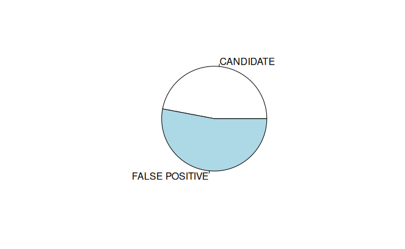

```r
pie(table(kepler$koi_pdisposition))
```

Comparando con el diagrama anterior, se puede ver que algunos de los candidatos han sido confirmados en el archivo de exoplanetas.

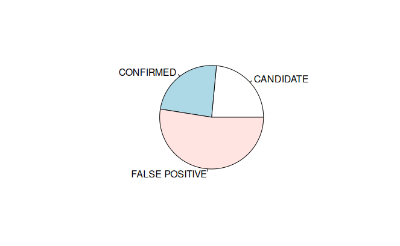

```r
pie(table(kepler$koi_disposition))
```

- **koi_score** es la confianza en que el planeta sea candidato, se distribuye como es de esperar de 0 a 1. Probabilidad (confianza) de que el objeto sea un planeta real. Para CANDIDATE un valor alto representa alta confianza, mientras para FALSE POSITIVE un valor bajo representa una confianza alta en la disposición.

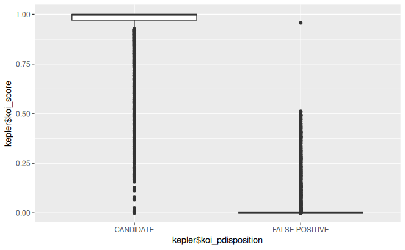

```r
kepler %>%
  ggplot(aes(x=kepler$koi_pdisposition,y=kepler$koi_score))+
  geom_boxplot()
```

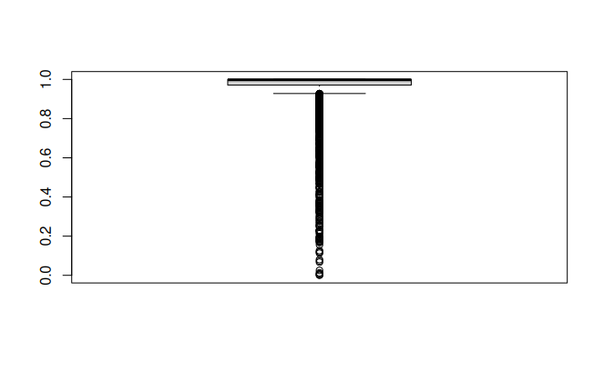

```r
kepler_pcandidate <- kepler %>%
  filter(koi_pdisposition == "CANDIDATE")
boxplot(kepler_pcandidate$koi_score)
```

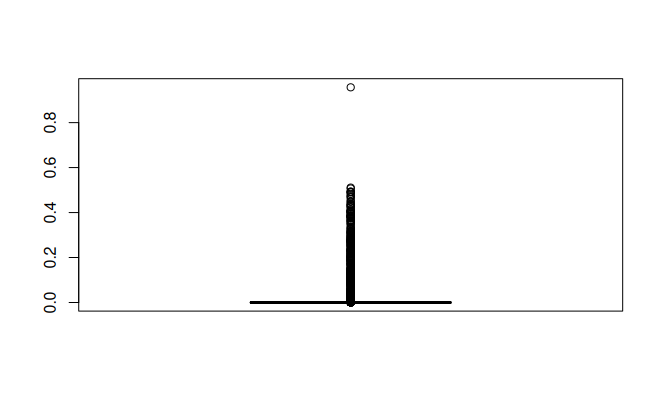

```r
kepler_pfps <- kepler %>%
  filter(koi_pdisposition == "FALSE POSITIVE")
boxplot(kepler_pfps$koi_score)
```

Una visualización sencilla: distribución de la duración del tránsito del exoplaneta, vemos cómo tiene un gran pico.

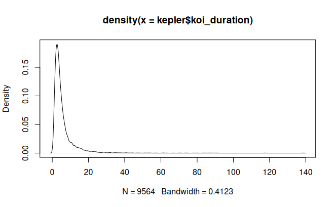

```r
plot(density(kepler$koi_duration))
```

# Seguimiento 2

**IMPORTANTE!!** La parte del seguimiento 1 ha sido ampliada, en especial se detallan mucho mejor las variables.

## TODO

- preprocesamiento: eliminar valores faltantes, NA, …
- verificar diferencias entre disposition y pdisposition y mirar koi_score (confianza) para estos ejemplos
- analizar razónes más comunes para FALSE POSITIVE con las columnas empezando en “koi_fpflag…”
- Analizar tránsitos, correlaciones
- hacer un predictor para CANDIDATE y FALSE POSITIVE con los datos de Kepler. En caso de un árbol de decisiones, cuáles son los atributos más importantes?
- clustering de planetas, estrellas, sistemas solares, ..
- … ?

## Introducción

Lo primero que probaremos será un clasificador sencillo binario de CANDIDATE/FALSE POSITIVE, para ello tenemos que eliminar la columna `koi_disposition`, pues también indica clases, pero de una forma distinta, como se describió anteriormente.

Debido al gran nº de nulos en el dataset, por ahora mientras estudiamos formas apropiadas de solventarlo, nos quedaremos con las columnas que no tengan ningún nulo.

```r
library(dplyr)

kepler_no_na_cols <- kepler %>%
  select(where(~ sum(is.na(.)) == 0))

colSums(is.na(kepler_no_na_cols))
```

```
           rowid            kepid       kepoi_name koi_pdisposition    koi_fpflag_nt    koi_fpflag_ss    koi_fpflag_co    koi_fpflag_ec       koi_period      koi_time0bk
               0                0                0                0                0                0                0                0                0                0
    koi_duration               ra              dec
               0                0                0
```

```r
ncol(kepler_no_na_cols)
```

[output not shown]

```r
kepler_no_na_cols$koi_disposition <- NULL
ncol(kepler_no_na_cols)
```

```
[1] 13
```

Como se ve, ahora tenemos un datframe con 13 columnas (12 para predecir) sin valores nulos y una columna `koi_pdisposition` que será la variable a prederir.

Vamos a empezar probando distintos modelos, para ello dividiremos nuestros datos en entrenamiento y prueba.

```r
library(caret)

myControl_clas <- trainControl(
  method = "cv",
  number = 10,
  summaryFunction = twoClassSummary,
  classProbs = TRUE, # IMPORTANT!
  savePredictions = TRUE,
  verboseIter = FALSE
)


model_clas_glm <- train(koi_pdisposition ~ ., kepler_no_na_cols,
                        method="glm",
                        trControl=myControl_clas)
```

[output not shown]

Entrenamos el siguiente modelo:

```r
model_clas_xgbTree <- train(koi_pdisposition ~ ., kepler_no_na_cols,
                        method="xgbTree",
                        trControl=myControl_clas)

print(model_clas_xgbTree)
```

[output not shown]

```r
model_list <- list(
  glm = model_clas_glm,
  glmnet = model_class_glmnet,
  glmnet_tunning = model_class_glmnet_tuning,
  xgbTree = model_clas_xgbTree
)
resamples <- resamples(model_list)

summary(resamples, metric="ROC")

# Representación visual
bwplot(resamples, metric = "ROC")
dotplot(resamples, metric="ROC")
```

[output not shown]

[output not shown]

### Valores Nulos

Mientras algunos trabajamos en esto, un compañero se encargó de estudiar como tratar los valores nulos, a continuación, lo que el hizo:

En Kaggle podemos ver que muchas columnas tiene NAs. Queremos saber si algunas muestras tienen NAs en muchas columnas - en este caso podríamos eliminar estas filas.

```r
kepler %>%
  mutate(missing_per_row = rowSums(is.na(.))) %>%
  arrange(desc(missing_per_row)) %>%
  head(20)
```

| rowid | kepid | kepoi_name | kepler_name | koi_disposition | koi_pdisposition | koi_score | koi_fpflag_nt | koi_fpflag_ss | koi_fpflag_co | koi_fpflag_ec | koi_period | koi_period_err1 | koi_period_err2 | koi_time0bk | koi_time0bk_err1 | koi_time0bk_err2 | koi_impact | koi_impact_err1 | koi_impact_err2 | koi_duration | koi_duration_err1 | koi_duration_err2 | koi_depth | koi_depth_err1 | koi_depth_err2 | koi_prad | koi_prad_err1 | koi_prad_err2 | koi_teq | … |
| --- | --- | --- | --- | --- | --- | --- | --- | --- | --- | --- | --- | --- | --- | --- | --- | --- | --- | --- | --- | --- | --- | --- | --- | --- | --- | --- | --- | --- | --- | --- |
| 330 | 6209637 | K01046.01 | NA | FALSE POSITIVE | FALSE POSITIVE | NA | 0 | 0 | 0 | 0 | 0.734525 | NA | NA | 133.4311 | NA | NA | NA | NA | NA | 6.70 | NA | NA | NA | NA | NA | NA | NA | NA | NA | … |
| 358 | 3235672 | K01109.01 | NA | FALSE POSITIVE | FALSE POSITIVE | NA | 0 | 0 | 0 | 0 | 6.721078 | NA | NA | 134.7776 | NA | NA | NA | NA | NA | 7.46 | NA | NA | NA | NA | NA | NA | NA | NA | NA | … |
| 477 | 3447722 | K01198.04 | NA | CANDIDATE | CANDIDATE | NA | 0 | 0 | 0 | 0 | 1.008617 | NA | NA | 132.1095 | NA | NA | NA | NA | NA | 0.91 | NA | NA | NA | NA | NA | NA | NA | NA | NA | … |
| 527 | 1027438 | K01010.01 | NA | FALSE POSITIVE | FALSE POSITIVE | NA | 0 | 0 | 0 | 0 | 110.615766 | NA | NA | 145.8354 | NA | NA | NA | NA | NA | 5.00 | NA | NA | NA | NA | NA | NA | NA | NA | NA | … |
| 556 | 8349405 | K01149.01 | NA | FALSE POSITIVE | FALSE POSITIVE | NA | 0 | 0 | 0 | 0 | 7.168827 | NA | NA | 136.2383 | NA | NA | NA | NA | NA | 1.29 | NA | NA | NA | NA | NA | NA | NA | NA | NA | … |
| 571 | 8179973 | K01019.01 | NA | FALSE POSITIVE | FALSE POSITIVE | NA | 0 | 0 | 0 | 0 | 2.497052 | NA | NA | 135.3073 | NA | NA | NA | NA | NA | 3.79 | NA | NA | NA | NA | NA | NA | NA | NA | NA | … |
| 742 | 10794087 | K01316.02 | NA | CANDIDATE | CANDIDATE | NA | 0 | 0 | 0 | 0 | 12.376793 | NA | NA | 143.3787 | NA | NA | NA | NA | NA | 3.85 | NA | NA | NA | NA | NA | NA | NA | NA | NA | … |
| 748 | 6880531 | K01372.01 | NA | FALSE POSITIVE | FALSE POSITIVE | NA | 0 | 0 | 0 | 0 | 69.627542 | NA | NA | 176.3099 | NA | NA | NA | NA | NA | 11.07 | NA | NA | NA | NA | NA | NA | NA | NA | NA | … |
| 817 | 11336883 | K01445.03 | NA | CANDIDATE | CANDIDATE | NA | 0 | 0 | 0 | 0 | 20.019596 | NA | NA | 150.8362 | NA | NA | NA | NA | NA | 7.00 | NA | NA | NA | NA | NA | NA | NA | NA | NA | … |
| 909 | 3440861 | K01219.01 | NA | FALSE POSITIVE | FALSE POSITIVE | NA | 0 | 0 | 0 | 0 | 3.503762 | NA | NA | 134.6826 | NA | NA | NA | NA | NA | 3.16 | NA | NA | NA | NA | NA | NA | NA | NA | NA | … |

[output cut: 10 more lines]

Aquí tenemos todos las columnas con los índices de muestras que contienen NA en esa columna:

```r
kepler_short <- kepler %>%
  select(-contains("err")) %>%
  select(-koi_tce_delivname)

kepler_na <- kepler_short %>%
  select(-kepler_name)

na_rows_by_col <- lapply(kepler_na, function(col) which(is.na(col)))
na_rows_by_col
```

```
$rowid
integer(0)

$kepid
integer(0)

$kepoi_name
integer(0)

$koi_disposition
integer(0)

$koi_pdisposition
integer(0)

$koi_score
   [1]   25   76  100  123  318  321  330  342  358  371  390  396  398  413  428  433  434  454  459  477  487  498  527  529  533  556  571  600  620  621  633  742  748
  [34]  816  817  826  844  861  862  880  903  909  914  918  931  948  957  965  971  996  997 1091 1110 1147 1162 1207 1228 1250 1489 1502 1509 1589 1612 1660 1693 1729
  [67] 1760 1868 1876 1877 1878 1887 1910 1921 1946 1953 1982 1984 2000 2001 2017 2076 2079 2108 2144 2165 2184 2192 2209 2265 2287 2326 2327 2331 2470 2649 2676 2693 2695
 [100] 2711 2801 3029 3039 3046 3100 3112 3118 3180 3184 3239 3327 3340 3571 3586 3592 3601 3604 3611 3621 3634 3648 3668 3675 3681 3689 3690 3700 3722 3736 3757 3759 3763
 [133] 3784 3786 3790 3792 3798 3799 3801 3803 3807 3808 3820 3824 3825 3826 3828 3831 3835 3836 3837 3842 3846 3852 3857 3860 3870 3871 3873 3888 3892 3893 3895 3896 3898
 [166] 3899 3902 3907 3921 3923 3935 3938 3941 3951 3960 3966 3970 3973 3992 3993 4004 4017 4025 4028 4031 4033 4034 4051 4054 4057 4058 4064 4069 4075 4081 4093 4095 4097
 [199] 4098 4100 4101 4113 4116 4125 4126 4129 4131 4136 4143 4145 4150 4157 4160 4161 4165 4172 4178 4179 4181 4192 4195 4202 4203 4208 4219 4231 4233 4236 4246 4248 4251
 [232] 4256 4258 4261 4264 4268 4270 4285 4294 4306 4307 4308 4317 4318 4324 4325 4328 4342 4344 4346 4351 4358 4362 4378 4383 4397 4400 4403 4440 4447 4448 4454 4466 4474
 [265] 4485 4494 4505 4507 4519 4525 4526 4528 4530 4546 4547 4548 4551 4553 4556 4560 4569 4573 4586 4593 4594 4604 4606 4614 4616 4618 4627 4628 4629 4631 4639 4657 4659
 [298] 4660 4662 4677 4691 4692 4695 4697 4703 4704 4716 4718 4719 4723 4733 4736 4803 4830 4843 4885 4954 4965 4973 5081 5082 5085 5115 5145 5153 5154 5221 5229 5364 5392
 [331] 5399 5400 5443 5471 5472 5490 5491 5493 5494 5499 5514 5517 5524 5538 5539 5542 5543 5556 5562 5592 5601 5602 5612 5629 5702 5714 5727 5728 5729 5746 5747 5748 5749
 [364] 5750 5751 5752 5753 5754 5755 5767 5779 5801 5804 5807 5808 5829 5832 5836 5837 5838 5843 5848 5849 5850 5852 5853 5854 5855 5857 5860 5862 5867 5868 5874 5876 5879
 [397] 5882 5883 5887 5888 5895 5897 5899 5900 5907 5910 5912 5916 5917 5919 5921 5922 5923 5925 5926 5927 5928 5929 5930 5932 5933 5934 5936 5937 5944 5945 5948 5949 5950
 [430] 5952 5953 5954 5955 5957 5960 5961 5962 5963 5965 5967 5968 5973 5974 5975 5976 5978 5980 5983 5984 5985 5986 5991 5993 5994 5996 5997 5998 6003 6004 6005 6008 6011
 [463] 6012 6013 6014 6015 6017 6020 6022 6026 6027 6028 6030 6031 6032 6033 6035 6036 6038 6041 6042 6043 6050 6055 6058 6059 6062 6065 6066 6068 6069 6070 6071 6072 6073
 [496] 6074 6075 6078 6079 6080 6081 6082 6084 6085 6087 6088 6089 6090 6091 6092 6094 6095 6097 6101 6103 6104 6105 6106 6108 6109 6110 6112 6115 6117 6118 6120 6121 6122
 [529] 6124 6125 6126 6128 6130 6131 6132 6134 6135 6137 6138 6139 6141 6144 6145 6147 6149 6151 6154 6155 6156 6158 6159 6160 6161 6163 6165 6166 6167 6168 6169 6170 6172
 [562] 6173 6174 6175 6176 6177 6178 6179 6180 6181 6183 6184 6185 6190 6191 6192 6194 6195 6197 6198 6199 6200 6202 6203 6204 6205 6207 6209 6210 6211 6213 6214 6216 6218
 [595] 6220 6221 6222 6223 6224 6225 6226 6229 6233 6238 6239 6245 6247 6248 6253 6254 6255 6256 6257 6259 6260 6261 6263 6264 6265 6275 6277 6279 6280 6281 6282 6283 6284
 [628] 6286 6287 6288 6289 6290 6292 6293 6294 6302 6304 6306 6307 6308 6309 6311 6312 6314 6315 6316 6319 6320 6321 6322 6323 6324 6325 6327 6328 6329 6331 6333 6334 6335
 [661] 6336 6338 6339 6340 6341 6342 6343 6345 6346 6347 6348 6349 6351 6352 6353 6357 6359 6360 6361 6362 6363 6364 6368 6369 6371 6372 6373 6374 6376 6378 6379 6380 6381
 [694] 6385 6386 6387 6390 6391 6392 6393 6394 6395 6396 6397 6399 6400 6401 6402 6405 6406 6408 6410 6411 6412 6413 6416 6417 6418 6419 6422 6423 6424 6425 6426 6427 6428
 [727] 6429 6431 6432 6434 6435 6436 6437 6438 6439 6440 6441 6443 6446 6447 6448 6449 6450 6451 6454 6456 6458 6459 6460 6462 6463 6464 6467 6471 6472 6474 6478 6480 6481
 [760] 6482 6483 6486 6487 6488 6490 6491 6493 6494 6497 6498 6501 6502 6503 6504 6505 6507 6508 6509 6510 6511 6513 6514 6515 6516 6517 6519 6521 6522 6524 6525 6526 6528
```

[output cut: 152 more lines]

```
[166] 6396 6399 6410 6412 6413 6416 6417 6435 6436 6437 6439 6440 6441 6446 6450 6486 6491 6498 6501 6507 6513 6521 6522 6524 6542 6543 6548 6549 6550 6556 6561 6583 6584
[199] 6594 6609 6613 6632 6640 6641 6642 6645 6652 6658 6659 6669 6675 6678 6693 6698 6700 6706 6708 6717 6720 6723 6749 6750 6762 6777 6788 6797 6799 6802 6805 6806 6816
[232] 6821 6825 6835 6855 6858 6860 6874 6882 6884 6899 6911 6912 6923 6939 6950 6981 6984 6989 7010 7020 7035 7045 7052 7064 7065 7066 7090 7096 7110 7138 7140 7147 7148
[265] 7150 7163 7166 7170 7180 7185 7192 7203 7226 7235 7248 7268 7270 7280 7294 7309 7312 7334 7361 7362 7390 7415 7431 7437 7450 7456 7458 7460 7479 7490 7518 7575 7578
[298] 7597 7605 7618 7625 7626 7627 7641 7648 7653 7685 7754 7758 7772 7784 7845 7853 7854 7863 7868 7870 7876 7933 7938 7941 7981 8038 8053 8057 8075 8078 8079 8092 8119
[331] 8124 8130 8148 8161 8195 8206 8211 8219 8227 8249 8261 8264 8272 8283 8293 8301 8302 8306 8308 8328 8335 8376 8406 8505 8651 8679 8989 9037 9065 9282 9315 9456 9486

$ra
integer(0)

$dec
integer(0)

$koi_kepmag
[1] 8640
```

Las columnas afectadas son las siguientes:

```r
cols_363 <- names(Filter(function(x) length(x) == 363, na_rows_by_col))
cols_363
```

```
[1] "koi_impact"    "koi_depth"     "koi_prad"      "koi_teq"       "koi_model_snr" "koi_steff"     "koi_slogg"     "koi_srad"
```

Aquí tenemos los índices de todas las muestras que tienen el valor NA en todas las columnas en las que NA es frecuente.

```r
rows_all_na <- kepler_na %>%
  filter(if_all(all_of(cols_363), is.na)) %>%
  pull(rowid)
rows_all_na
```

```
  [1]  330  358  477  491  493  527  556  571  742  748  817  909  957  965  997 1091 1228 1250 1489 1509 1589 1660 1876 1877 1910 1921 1982 1984 2001 2184 2724 3039 3112
 [34] 3118 3184 3244 3591 3621 3681 3759 3881 3893 4017 4033 4034 4400 4519 4639 4660 4662 4803 4830 4843 4888 4971 5004 5082 5154 5229 5256 5345 5360 5364 5367 5410 5471
 [67] 5472 5491 5493 5514 5517 5538 5539 5556 5592 5629 5727 5728 5729 5746 5747 5748 5749 5751 5752 5753 5754 5755 5779 5801 5829 5836 5837 5838 5843 5849 5852 5853 5854
[100] 5857 5860 5868 5876 5879 5882 5883 5900 5917 5921 5926 5927 5928 5954 5963 5966 5978 5986 5998 6004 6020 6030 6062 6065 6068 6080 6082 6083 6084 6090 6108 6122 6134
[133] 6137 6161 6167 6189 6202 6204 6205 6209 6223 6245 6247 6256 6257 6280 6283 6288 6290 6294 6302 6323 6325 6327 6328 6335 6339 6345 6347 6349 6360 6371 6380 6387 6394
[166] 6396 6399 6410 6412 6413 6416 6417 6435 6436 6437 6439 6440 6441 6446 6450 6486 6491 6498 6501 6507 6513 6521 6522 6524 6542 6543 6548 6549 6550 6556 6561 6583 6584
[199] 6594 6609 6613 6632 6640 6641 6642 6645 6652 6658 6659 6669 6675 6678 6693 6698 6700 6706 6708 6717 6720 6723 6749 6750 6762 6777 6788 6797 6799 6802 6805 6806 6816
[232] 6821 6825 6835 6855 6858 6860 6874 6882 6884 6899 6911 6912 6923 6939 6950 6981 6984 6989 7010 7020 7035 7045 7052 7064 7065 7066 7090 7096 7110 7138 7140 7147 7148
[265] 7150 7163 7166 7170 7180 7185 7192 7203 7226 7235 7248 7268 7270 7280 7294 7309 7312 7334 7361 7362 7390 7415 7431 7437 7450 7456 7458 7460 7479 7490 7518 7575 7578
[298] 7597 7605 7618 7625 7626 7627 7641 7648 7653 7685 7754 7758 7772 7784 7845 7853 7854 7863 7868 7870 7876 7933 7938 7941 7981 8038 8053 8057 8075 8078 8079 8092 8119
[331] 8124 8130 8148 8161 8195 8206 8211 8219 8227 8249 8261 8264 8272 8283 8293 8301 8302 8306 8308 8328 8335 8376 8406 8505 8651 8679 8989 9037 9065 9282 9315 9456 9486
```

Podemos borrar estas muestras del dataset y vemos que solo quedan 3 atributos afectados de NA.

```r
kepler_na_clean1 <- kepler_na %>%
  filter(!rowid %in% rows_all_na)

na_rows_by_col_clean1 <- lapply(kepler_na_clean1, function(col) which(is.na(col)))
na_rows_by_col_clean1
```

```
$rowid
integer(0)

$kepid
integer(0)

$kepoi_name
integer(0)

$koi_disposition
integer(0)

$koi_pdisposition
integer(0)

$koi_score
   [1]   25   76  100  123  318  321  341  369  388  394  396  411  426  431  432  452  457  484  493  523  527  592  612  613  625  806  815  833  850  851  869  892  902
  [34]  906  919  936  957  982 1094 1131 1146 1191 1483 1591 1671 1707 1738 1846 1854 1863 1920 1927 1972 1988 2047 2050 2079 2115 2136 2162 2179 2235 2257 2296 2297 2301
  [67] 2440 2619 2646 2663 2665 2681 2770 2998 3014 3068 3146 3204 3291 3304 3535 3550 3555 3564 3567 3574 3596 3610 3630 3637 3650 3651 3661 3683 3697 3718 3723 3744 3746
 [100] 3750 3752 3758 3759 3761 3763 3767 3768 3780 3784 3785 3786 3788 3791 3795 3796 3797 3802 3806 3812 3817 3820 3830 3831 3833 3847 3851 3853 3854 3856 3857 3860 3865
 [133] 3879 3881 3893 3896 3899 3909 3918 3924 3928 3931 3950 3951 3962 3982 3985 3988 4006 4009 4012 4013 4019 4024 4030 4036 4048 4050 4052 4053 4055 4056 4068 4071 4080
 [166] 4081 4084 4086 4091 4098 4100 4105 4112 4115 4116 4120 4127 4133 4134 4136 4147 4150 4157 4158 4163 4174 4186 4188 4191 4201 4203 4206 4211 4213 4216 4219 4223 4225
 [199] 4240 4249 4261 4262 4263 4272 4273 4279 4280 4283 4297 4299 4301 4306 4313 4317 4333 4338 4352 4357 4394 4401 4402 4408 4420 4428 4439 4448 4459 4461 4478 4479 4481
 [232] 4483 4499 4500 4501 4504 4506 4509 4513 4522 4526 4539 4546 4547 4557 4559 4567 4569 4571 4580 4581 4582 4584 4609 4611 4627 4641 4642 4645 4647 4653 4654 4666 4668
 [265] 4669 4673 4683 4686 4832 4900 4911 4918 5025 5028 5058 5088 5096 5163 5328 5335 5336 5378 5423 5425 5430 5453 5469 5470 5488 5526 5527 5537 5626 5638 5667 5679 5714
 [298] 5717 5718 5741 5753 5754 5756 5761 5766 5772 5781 5782 5789 5791 5793 5800 5803 5805 5809 5811 5813 5814 5816 5817 5818 5820 5821 5822 5824 5825 5832 5833 5836 5837
 [331] 5838 5840 5841 5842 5844 5847 5848 5849 5851 5852 5853 5858 5859 5860 5861 5864 5867 5868 5869 5874 5876 5877 5879 5880 5885 5886 5889 5892 5893 5894 5895 5896 5898
 [364] 5902 5906 5907 5908 5910 5911 5912 5914 5915 5917 5920 5921 5922 5929 5934 5937 5938 5943 5945 5946 5947 5948 5949 5950 5951 5954 5955 5956 5957 5959 5960 5961 5962
 [397] 5963 5965 5966 5968 5972 5974 5975 5976 5977 5979 5980 5982 5985 5987 5988 5990 5991 5993 5994 5995 5997 5999 6000 6001 6003 6005 6006 6008 6011 6012 6014 6016 6018
 [430] 6021 6022 6023 6025 6026 6027 6029 6031 6032 6033 6034 6035 6037 6038 6039 6040 6041 6042 6043 6044 6045 6046 6048 6049 6050 6054 6055 6056 6058 6059 6061 6062 6063
 [463] 6064 6066 6068 6070 6071 6073 6074 6076 6078 6080 6081 6082 6083 6084 6085 6088 6092 6097 6098 6105 6110 6111 6112 6114 6115 6116 6118 6119 6120 6130 6132 6134 6135
 [496] 6136 6137 6139 6140 6141 6143 6144 6153 6155 6156 6157 6158 6160 6161 6163 6164 6165 6168 6169 6170 6171 6172 6174 6176 6178 6179 6180 6182 6183 6184 6185 6186 6188
 [529] 6189 6191 6192 6193 6197 6199 6200 6201 6202 6203 6207 6208 6210 6211 6212 6214 6216 6217 6218 6222 6223 6226 6227 6228 6229 6230 6231 6233 6234 6235 6238 6239 6241
 [562] 6243 6246 6247 6250 6251 6252 6253 6254 6255 6256 6257 6259 6260 6262 6263 6265 6268 6269 6270 6271 6274 6276 6278 6279 6280 6282 6283 6284 6287 6291 6292 6294 6298
 [595] 6300 6301 6302 6303 6306 6307 6309 6311 6312 6315 6318 6319 6320 6321 6323 6324 6325 6326 6328 6329 6330 6331 6333 6336 6337 6339 6340 6341 6344 6345 6346 6348 6350
 [628] 6351 6352 6354 6356 6357 6358 6363 6364 6366 6368 6369 6370 6371 6372 6373 6376 6378 6380 6382 6383 6385 6386 6389 6390 6391 6393 6395 6397 6399 6400 6402 6403 6404
 [661] 6411 6413 6414 6415 6416 6417 6420 6424 6425 6426 6427 6428 6429 6433 6435 6436 6438 6439 6440 6442 6443 6444 6448 6450 6451 6452 6457 6458 6460 6461 6463 6464 6467
 [694] 6469 6470 6471 6474 6476 6478 6479 6484 6485 6486 6487 6488 6489 6491 6492 6493 6495 6497 6498 6499 6500 6503 6504 6507 6508 6510 6511 6512 6513 6514 6515 6516 6518
 [727] 6521 6523 6524 6525 6526 6527 6528 6529 6530 6533 6534 6536 6537 6540 6541 6542 6544 6545 6547 6548 6549 6550 6551 6552 6553 6555 6558 6559 6560 6561 6562 6565 6567
 [760] 6568 6569 6570 6571 6572 6574 6576 6577 6578 6579 6581 6582 6585 6587 6588 6589 6590 6591 6592 6593 6594 6595 6596 6602 6605 6606 6607 6608 6609 6610 6611 6612 6613
```

[output cut: 60 more lines]

```

$koi_slogg
integer(0)

$koi_srad
integer(0)

$ra
integer(0)

$dec
integer(0)

$koi_kepmag
[1] 8286
```